# Generación Entorno Docker

Trabajo realizado por:

- *Sergio Ranz Casado*
- *Marcos Medina Cogolludo*

## GENERACIÓN ENTORNO DOCKER

Una vez tenemos la API creada vamos a generar un entorno Docker donde poder trabajar y poder ejecutar todo correctamente salvando las dependencias de sistemas operativos, librerías, entornos, etc.

Para la creación del entorno DOCKER solo necesitamos dos archivos adiccionales a los que ya tenemos.

- Dockerfile: Archivo muy parecido al txt, que contiene la configuración de la imagen del contenedor.
- Requirements.txt: Archivo txt que contiene las librerias necesarias para la ejecución de nuestra API asi como la ejecución de nuestro modelo.

#### 1.) Creación de Dockerfile:

Para la creación del Dockerfile vamos a usar Visual Studio Code. Ya que el propio editor sabe identificarte el tipo de archivo. Una vez creado. Deberemos guardarlo como **Dockerfile** no valen archivos llamados como *(1.Dockerfile, .Dockerfile, DOCKERFILE o dockerfile).*

A continuación comentamos la configuración de nuestro Dockerfile:

- `FROM Ubuntu`: Escogemos la distribución base de Linux, si bien es cierto que aqui se pueden escoger varias opciones `python:versión que necesitas`, `alpine`, incluso distribuciones como centos o windows tambien son valias. Aqui va mas en función de como trabajan. Nosotros probamos alpine y python y no nos terminaron de convencer. Nos decantamos por Ubuntu al final.
- `ADD . /accidentes_api`. Incluimos la carpeta donde localizamos el modelo y la API.
- `WORKDIR /accidentes_api`. Incluimos como directorio de trabajo la carpeta donde localizamos el modelo y la API.

- ```
  RUN apt-get update && apt-get install python3.6 -y && apt-get install python3-pip -y
   RUN apt-get install vim -y
   RUN pip3 install -r requirements.txt
  ```

  . Este comado lo incluimos para instalar todas las carpetas necesarias en requirements.txt. En los siguientes pasos de este tutorial mostramos como hemos creado la carpeta requirements.txt.
- `CMD ["/bin/bash"]` Este comando se encarga de pasar valores por defecto a un contenedor. Entre estos valores se pueden pasar ejecutables. Como hemos escogido Linux, el comando CMD será `/bin/bash`.

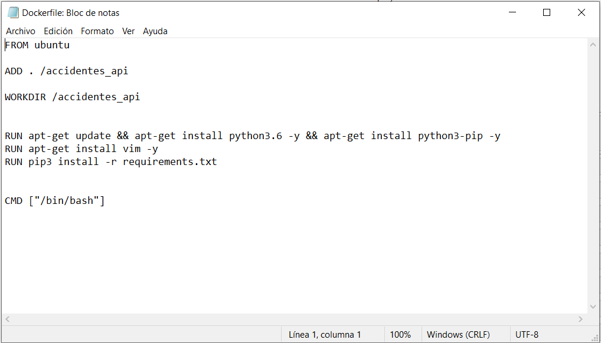

#### 2.) Creación requierements.txt

El fichero requirements es un fichero formato txt que contiene las librerias requeridas para ejecutar la API. Nosotros hemos escogido las siguientes librerias:

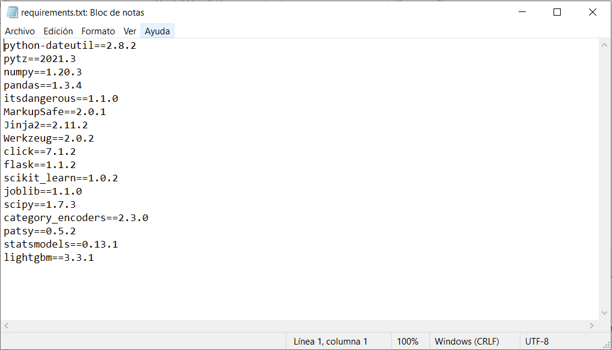

#### 3.) Creación de Imagen del contenedor y ejecución:

Una vez tenemos todos los ficheros necesarios. Abrimos la consola `POWERSHELL` desde la que crearemos la imagen del contenedor y ejecutaremos el mismo. Los pasos a seguir son los siguientes:

- Con el comando `cd` vamos hacia la carpeta donde tenemos todos los archivos.
- Ejecutamos el comando: `docker build -t NOMBRE-QUE-QUERAMOS .`. Este comando servirá para crear la imagen la cual ejecutará el dockerfile creado anteriormente e instalará todas las librerias que hemos requerido en el archivo requirements.txt. Si nos ha salido de manera correcta obtendremos esta respuesta:

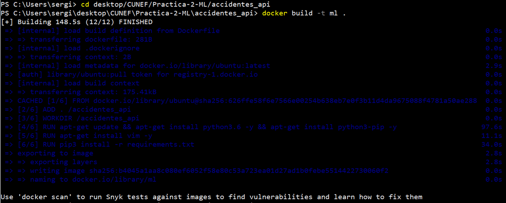

- A continuación, para correr la imagen del contenedor creado, ejecutamos el siguiente comando: `docker run -it -p 3306:3306 NOMBRE-CONTENEDOR bash`.
- Una vez ejecutado el comando, obtendremos una root: En el que introduciremos el comando `python3 app.py` Para ejecutar la API desde el docker: obtendremos una respuesta en forma de URL:

*OJO: En la creación de la imagen nosotros hemos tenido muchos problemas con los puertos. En un inicio introducimos el puerto 5000:5000, pero al ejecutar la URL en POSTMAN no nos aparecia la respuesta del servidor, por lo que decidimos probar con 3306:3306. Otra opción seria probar con 8888:8888.*

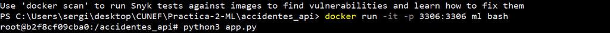

Respuesta...

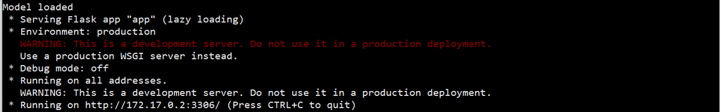

4.) Comprobamos que todo va bien con POSTMAN. Sin embargo, al ejecutar la URL `http://172.17.0.2:3306/predict` obtenemos el siguiente error:

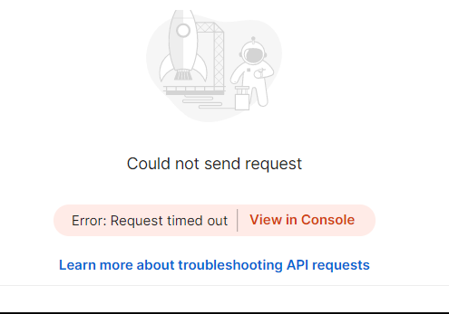

Esto se debe a que no hemos introducido de manera correcta la URL del servidor. Si nos fijamos en Docker Desktop y vamos a la ejecución del contenedor. Vemos en sus propiedades que la URL del contenedor es la siguiente:

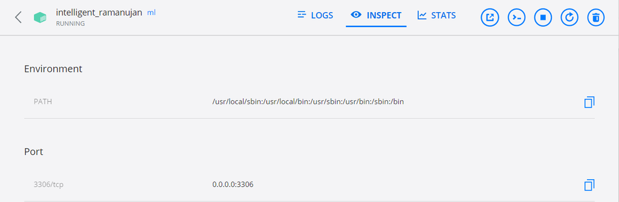

Por lo que en POSTMAN deberemos de introducir la URL: `http://0.0.0.0:3306/predict`. Ahora si obtenemos la respuesta del servidor y la predicción igual que en la API:

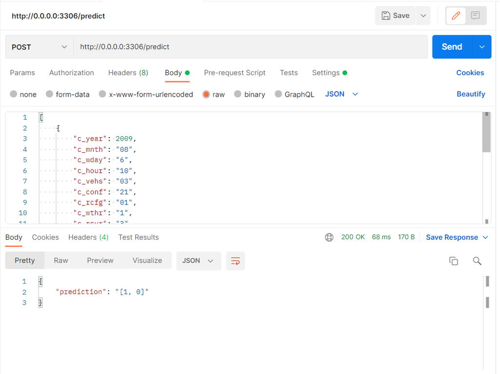

Para comprobar que todo se ha ejecutado correctamente, vamos a POWERSHELL: Donde, al igual que en la API, nos mostrará la petición que hemos realizado:

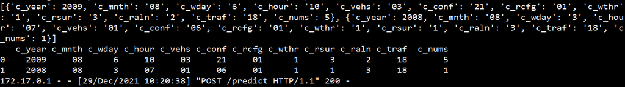

#### ENLACES DE INTERÉS:

[`Deploy your Flask REST API on Docker`](https://medium.com/nerd-for-tech/deploy-your-flask-rest-api-on-docker-909f5cfa8b0b)

[`Comandos RUN, CMD y ENTRYPOINT en el Dockerfile`](https://dockertips.com/comandos-run-cmd-y-entrypoint-en-el-dockerfile)

[`Docker Documentation`](https://docs.docker.com/engine/reference/commandline/run/#publish-or-expose-port--p---expose)

[`Build and Run a Docker Container for your Machine Learning Model`](https://towardsdatascience.com/build-and-run-a-docker-container-for-your-machine-learning-model-60209c2d7a7f)

[`How I Created a Python Development Environment with Docker`](https://www.tutorialworks.com/python-develop-container/)